# Tesis escritura anexo

# Anexo

## 2. Metodología

### Librerías requeridas

```r
# paquetes ==========================================================
# manejo de datos
library(tidyverse)
# estadísticos descriptivos ponderados
library(matrixStats)
# definir como encuesta de diseño complejo
library(srvyr)
# paleta de colores
library(RColorBrewer)
# letter value plot
library(lvplot)
# regresión
library(modelr)
library(survey) # encuesta disenio complejo
# análisis de residuos
library(performance)
library(car)
library(stats)
library(nortest)
library(moments) # coeficiente asimetría
library(lmtest)
library(see)
# convertir a porcentaje dentro de mutate
library(scales)
library(gt)
# mapas geográficos
library(sf)
library(rnaturalearth)
library(rnaturalearthdata)
library(rnaturalearthhires)
```

### Fuente de datos

```r
# importación =======================================================
# 3. sociodemográfica
sdem <- read_csv(
  "ENOE_SDEMT225.csv",
  col_types = cols(.default = col_character())
)

# 4. ocupación y empleo I
coe1 <- read_csv(
  "ENOE_COE1T225.csv",
  col_types = cols(.default = col_character())
)

# 5. ocupación y empleo II
coe2 <- read_csv(
  "ENOE_COE2T225.csv",
  col_types = cols(.default = col_character())
)
```

### Construcción de variables

```r
# construcción de variables =========================================
# grupos de edadd OECD(2019: 135)
sdem <- sdem %>%
  mutate(
    edad = as.integer(eda),
    edad_7g = case_when(
      between(edad, 0, 14) ~ "1",
      between(edad, 15, 24) ~ "2",
      between(edad, 25, 34) ~ "3",
      between(edad, 35, 44) ~ "4",
      between(edad, 45, 54) ~ "5",
      between(edad, 55, 64) ~ "6",
      between(edad, 65, 97) ~ "7",
      # edad no especificada mayores a 12 INEGI(2024:16)
      edad == "98" ~ "98",
      # edad no especificada menores a 12 INEGI(2024:16)
      edad == "99" ~ "99",
      # NA sin comillas para valores faltantes
      TRUE ~ NA
    )
  )

# carreras universitaria INEGI(2016: 13)
sdem <- sdem %>%
  mutate(
    carrera1 = if_else(str_length(cs_p14_c) == 5, str_c("0", cs_p14_c), cs_p14_c),
    carrera2 = if_else(str_length(cs_p14_c) == 5, str_c("0", cs_p14_c), cs_p14_c),
    carrera3 = if_else(str_length(cs_p14_c) == 5, str_c("0", cs_p14_c), cs_p14_c)
  ) %>%
  separate(
    carrera1,
    # campo amplio
    into = c("carrera1", "res"),
    sep = 2
  ) %>%
  separate(
    carrera2,
    # campo específico
    into = c("carrera2", "res"),
    sep = 3
  ) %>%
  separate(
    carrera3,
    # campo detallado
    into = c("carrera3", "res"),
    sep = 4
  ) %>%
  select(-res)

# grupos ocupacionales INEGI(2019: 22)
coe1 <- coe1 %>%
  mutate(
    ocupacion1 = p3,
    ocupacion2 = p3,
    ocupacion3 = p3
  ) %>%
  separate(
    ocupacion1,
    into = c("ocupacion1", "res"),
    sep = 1
  ) %>%
  separate(
    ocupacion2,
    into = c("ocupacion2", "res"),
    sep = 2
  ) %>%
  separate(
    ocupacion3,
    into = c("ocupacion3", "res"),
    sep = 3
  ) %>%
  select(-res)
```

#### Creación de tablas

```r
# creación de tablas ================================================
# población de 12 y más para unir sdem y coe INEGI(2023:9)
pob_12ymas <- sdem %>%
  filter(
  r_def == "0",
  c_res != "2",
  between(edad, 12, 98)
  )

# nrow(pob_12ymas)
# nrow(coe1)

# población total INEGI(2023:21)
pob_total <- sdem %>%
  filter(
    r_def == "0",
    # es igual a (c_res == "1" | c_res == "3")
    c_res != "2"
  )

# población de 12 y más para unir sdem y coe INEGI(2023:9)
pob_12ymas <- sdem %>%
  filter(
  r_def == "0",
  c_res != "2",
  between(edad, 12, 98)
  )

# unión de sdem y coe INEGI(2023:9)
completo <- pob_12ymas %>%
  full_join(coe1, by = c("tipo", "mes_cal", "cd_a", "ent", "con", "v_sel", "n_hog", "h_mud", "n_ren")) %>%
  full_join(coe2, by = c("tipo", "mes_cal", "cd_a", "ent", "con", "v_sel", "n_hog", "h_mud", "n_ren"))

# población de 15 años y más INEGI(2023:21)
pob_15ymas <- completo %>%
  filter(
    r_def.x == "0",
    c_res != "2",
    between(edad, 15, 98)
  )

# INEGI(2023: 21)
ocupada <- pob_15ymas %>%
  filter(clase2 == 1)

# INEGI(2023: 25)
desocupada <- pob_15ymas %>%
  filter(clase2 == 2)

# INEGI(2023: 26)
pnea <- pob_15ymas %>%
  filter(clase1 == 2)
```

### Segmentación

```r
# segmentación ======================================================
ocupada <- ocupada %>% mutate(
  # edad
  edad = as.integer(eda),
  # años de estudios
  anios_estudios = as.integer(anios_esc),
  # 99 pasa a NA para evitar 99 - edu_req
  anios_estudios = if_else(anios_estudios != 99, anios_estudios, NA),
  # grado escolar
  escolaridad = as.integer(cs_p13_1),
  # 99 pasa a NA para evitar 99 - edu_req
  escolaridad = if_else(escolaridad != 99, escolaridad, NA),
  # ponderador trimestral
  fac_tri = as.double(fac_tri),
  # ingreso mensual
  ingreso_mensual = as.double(ingocup),
  # 0 pasa a NA ya que 0==NA en p6b2
  ingreso_mensual = if_else(ingreso_mensual != 0, ingreso_mensual, NA),
  # promedio de ingreso por hora
  ingreso_hora = as.double(ing_x_hrs),
  # 0 pasa a NA ya que 0==NA en p6b2 y en dur9c == 1 & 9
  ingreso_hora = if_else(ingreso_hora != 0, ingreso_hora, NA)
)
```

#### Eliminación de variables duplicadas

```r
ocupada <- ocupada %>%
  select(-contains(".x"), -contains(".y"))

# ncol(ocupada)
```

### Método objetivo

```r
# método: objetivo --------------------------------------------------
# con el grupo división INEGI(2020: 22)
educacion_req_objetivo <- ocupada %>%
  group_by(ocupacion1) %>%
  summarise(total = sum(fac_tri)) %>%
  mutate(
    objetivo_min = case_when(
      ocupacion1 == 1 ~ 5,
      ocupacion1 == 2 ~ 5,
      ocupacion1 == 3 ~ 3,
      ocupacion1 == 4 ~ 3,
      ocupacion1 == 5 ~ 3,
      ocupacion1 == 6 ~ 3,
      ocupacion1 == 7 ~ 3,
      ocupacion1 == 8 ~ 3,
      ocupacion1 == 9 ~ 2,
      TRUE ~ NA
    ),
    objetivo_max = case_when(
      ocupacion1 == 1 ~ 9,
      ocupacion1 == 2 ~ 9,
      ocupacion1 == 3 ~ 4,
      ocupacion1 == 4 ~ 4,
      ocupacion1 == 5 ~ 4,
      ocupacion1 == 6 ~ 4,
      ocupacion1 == 7 ~ 4,
      ocupacion1 == 8 ~ 4,
      ocupacion1 == 9 ~ 2,
      TRUE ~ NA
    )
  ) %>%
  select(-total)

# comprobación
educacion_req_objetivo
```

```
## # A tibble: 9 × 3
##   ocupacion1 objetivo_min objetivo_max
##   <chr>             <dbl>        <dbl>
## 1 1                     5            9
## 2 2                     5            9
## 3 3                     3            4
## 4 4                     3            4
## 5 5                     3            4
## 6 6                     3            4
## 7 7                     3            4
## 8 8                     3            4
## 9 9                     2            2
```

### Determinación de la incidencia

#### Objetivo

```r
# desajuste educativo con el método objetivo
objetivo <- ocupada %>% left_join(educacion_req_objetivo, by = "ocupacion1") %>%
  mutate(
    desajuste_educativo = case_when(
      # required
      between(escolaridad, objetivo_min, objetivo_max) ~ 0,
      # over
      escolaridad > objetivo_max ~ 1,
      # under
      escolaridad < objetivo_min ~ 2,
      TRUE ~ NA
    ),
    # variables binarias
    over_obj = if_else(escolaridad > objetivo_max, 1, 0),
    required_obj = if_else(between(escolaridad, objetivo_min, objetivo_max), 1, 0),
    under_obj = if_else(escolaridad < objetivo_max, 1, 0)
    # variables de años de sobre o infra
    # objetivo: no se puede obtener ya que son grados y están en intervalos
  )
```

### Efecto salarial

#### Construcción de las demás variables explicativas

```r
# otras variables explicativas ======================================

# objetivo ------------------------------------------------
objetivo <- objetivo %>%
  mutate(
    # horas trabajadas
    # 999 indica no específicado, se convierte a NA INEGI(2024:81)
    horas_lab = if_else(p5b_thrs != 999, p5b_thrs, NA),
    horas_lab = as.double(horas_lab),
    # experiencia laboral potencial
    # si es <= 0, se convierte a NA; no afecta al grupo de jóvenes
    # si edad == 98, se convierte a NA
    # experiencia = edadd - años estudios - 6
    # Zamudio e Islas(1999) y Mincer(1974)
    exper = edad - anios_estudios - 6,
    exper = if_else(exper > 0 & edad != 98, exper, NA),
    # experiencia ^ 2 para que el ingreso tenga una forma de U
    exper2 = exper ** 2,
    # género == 1 si es hombre
    hombre = if_else(sex == 1, 1, 0),
    # estado civil == 1 si es casadao
    casada = if_else(e_con == 5, 1, 0),
    # situación de hogar == 1 si es jefe INEGI(2020:37)
    jefe_hogar = if_else(par_c == 101, 1, 0),
    # variables dicotómicas para los grupos ocupacionales
    # grupo de referencia: 9 INEGI(2020: 27)
    func_dir_jefes = if_else(ocupacion1 == 1, 1, 0),
    prof_tecnicos = if_else(ocupacion1 == 2, 1, 0),
    aux_admin = if_else(ocupacion1 == 3, 1, 0),
    comerc_ventas = if_else(ocupacion1 == 4, 1, 0),
    serv_vig = if_else(ocupacion1 == 5, 1, 0),
    agric_gan_for = if_else(ocupacion1 == 6, 1, 0),
    art_constr = if_else(ocupacion1 == 7, 1, 0),
    maq_ens = if_else(ocupacion1 == 8, 1, 0),
    elementales = if_else(ocupacion1 == 9, 1, 0)
  )
```

### Definición como encuesta de diseño complejo

```r
# objetivo ------------------------------------------------
# encuesta de disenio complejo
objetivo <- objetivo %>%
  as_survey_design(
    ids = upm,
    strata = est,
    weights = fac_tri,
    nest = TRUE
  )
```

# Resultados

## General

```r
objetivo %>%
  group_by(desajuste_educativo) %>%
  summarise(
    n = n(),
    tot = survey_total(vartype = "ci"),
    prop = survey_prop(vartype = NULL)
  )
```

```
## # A tibble: 4 × 6
##   desajuste_educativo      n      tot   tot_low   tot_upp    prop
##                 <dbl>  <int>    <dbl>     <dbl>     <dbl>   <dbl>
## 1                   0 106832 33063892 32264873. 33862911. 0.556
## 2                   1  50004 15105783 14677714. 15533852. 0.254
## 3                   2  33488 11162745 10779283. 11546207. 0.188
## 4                  NA    363   108340    85513.   131167. 0.00182
```

Por sexo

```r
resultado2 <- objetivo %>%
  group_by(sex, desajuste_educativo) %>%
  summarise(
    n = n(),
    tot = sum(fac_tri)
  ) %>%
  mutate(prop = tot / sum(tot))

resultado2
```

```
## # A tibble: 8 × 5
## # Groups:   sex [2]
##   sex   desajuste_educativo     n      tot    prop
##   <chr>               <dbl> <int>    <dbl>   <dbl>
## 1 1                       0 61000 19047486 0.543
## 2 1                       1 26684  8177325 0.233
## 3 1                       2 23358  7815906 0.223
## 4 1                      NA   233    69192 0.00197
## 5 2                       0 45832 14016406 0.576
## 6 2                       1 23320  6928458 0.285
## 7 2                       2 10130  3346839 0.138
## 8 2                      NA   130    39148 0.00161
```

```r
  # filter(desajuste_educativo == 1)
```

Por edad

```r
resultado3 <- objetivo %>%
  group_by(edad_7g, desajuste_educativo) %>%
  summarise(
    n = n(),
    tot = sum(fac_tri)
  ) %>%
  mutate(prop = tot / sum(tot))

resultado3
```

```
## # A tibble: 28 × 5
## # Groups:   edad_7g [7]
##    edad_7g desajuste_educativo     n     tot    prop
##    <chr>                 <dbl> <int>   <dbl>   <dbl>
##  1 2                         0 15491 4703881 0.542
##  2 2                         1 10473 3215691 0.370
##  3 2                         2  2314  750641 0.0864
##  4 2                        NA    39   13398 0.00154
##  5 3                         0 26533 8191616 0.599
##  6 3                         1 13441 4105546 0.300
##  7 3                         2  4185 1367873 0.1000
##  8 3                        NA    56   17405 0.00127
##  9 4                         0 26719 8303531 0.602
## 10 4                         1 11269 3356222 0.243
## # ℹ 18 more rows
```

```r
  # filter(desajuste_educativo == 1)
```

De forma gráfica

[output not shown]

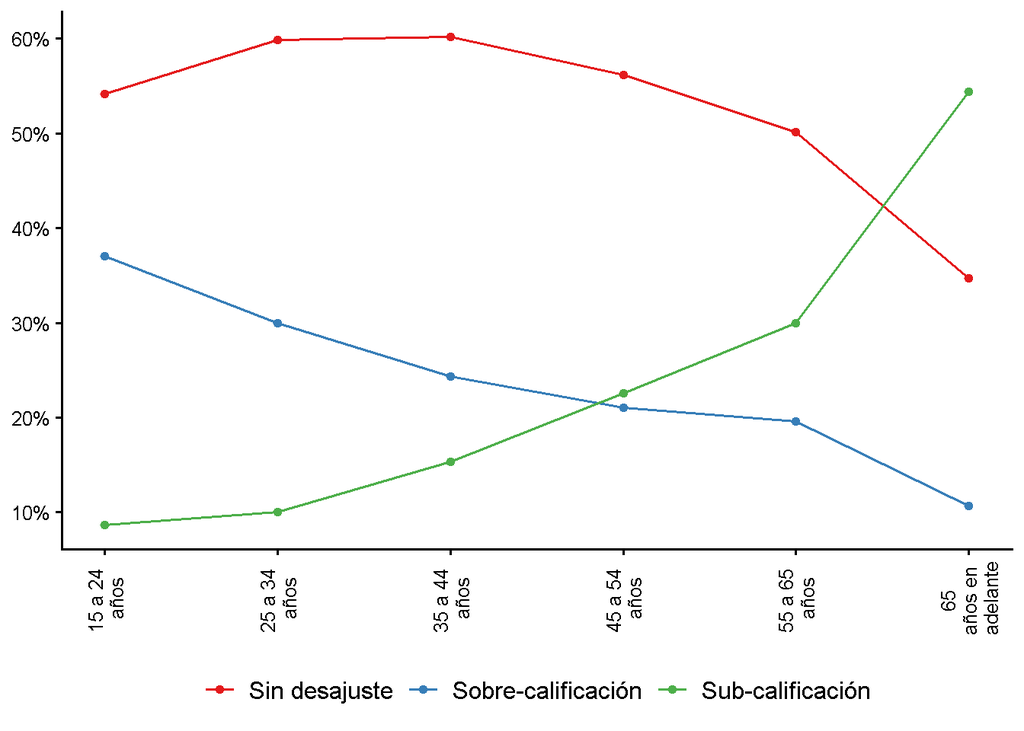

```r
labels_vars1 <- c(
  "2" = "15 a 24 \naños",
  "3" = "25 a 34 \naños",
  "4" = "35 a 44 \naños",
  "5" = "45 a 54 \naños",
  "6" = "55 a 65 \naños",
  "7" = "65 \naños en \nadelante"
  )

labels_vars2 <- c(
  "0" = "Sin desajuste",
  "1" = "Sobre-calificación",
  "2" = "Sub-calificación"
)

resultado3 %>%
  filter(edad_7g != 98 & !is.na(desajuste_educativo)) %>%
  mutate(
    edad_7g = as.integer(edad_7g),
    desajuste_educativo = factor(desajuste_educativo)
  ) %>%
  ggplot(aes(edad_7g, prop, color = desajuste_educativo)) +
  geom_point() +
  geom_line() +
  scale_x_continuous(labels = labels_vars1) +
  scale_y_continuous(
    labels = scales::label_percent(),
    breaks = seq(0, 0.6, by = 0.1)
  ) +
  scale_color_brewer(
    palette = "Set1",
    name = NULL,
    labels = labels_vars2
  ) +
  theme_classic(base_size = 12, base_family = "Trebuchet MS") +
  theme(
    axis.text.x = element_text(angle = 90, vjust = 0.5),
    legend.position = "bottom",
    legend.text = element_text(size = 12)
  ) +
  labs(
    x = NULL,
    y = NULL
  )
```

```r
ggsave(
  "incidencia_general_edad.png",
  width = 17,
  height = 10,
  units = "cm"
)
```

Por escolaridad

```r
resultado4 <- objetivo %>%
  group_by(escolaridad, desajuste_educativo) %>%
  summarise(
    n = n(),
    tot = sum(fac_tri)
  ) %>%
  mutate(prop = tot / sum(tot))

resultado4
```

```
## # A tibble: 21 × 5
## # Groups:   escolaridad [11]
##    escolaridad desajuste_educativo     n      tot   prop
##          <int>               <dbl> <int>    <dbl>  <dbl>
##  1           0                   2  4286  1553588 1
##  2           1                   2    84    23663 1
##  3           2                   0  9547  3343652 0.332
##  4           2                   2 19531  6714343 0.668
##  5           3                   0 33981 10481271 0.651
##  6           3                   1 14476  4631214 0.288
##  7           3                   2  3367   982093 0.0610
##  8           4                   0 32117  9757615 0.688
##  9           4                   1  8284  2528897 0.178
## 10           4                   2  6220  1889058 0.133
## # ℹ 11 more rows
```

```r
  # filter(desajuste_educativo == 0)
  # mutate(
  #   escolaridad = factor(escolaridad),
  #   escolaridad = fct_recode(
  #     escolaridad,
  #       "Ninguna"="0",
  # "Preescolar"="1",
  # "Primaria"="2",
  # "Secundaria"="3",
  # "Preparatoria"="4",
  # "Normal"="5",
  # "Carrera técnica"="6",
  # "Profesional"="7",
  # "Maestría"="8",
  # "Doctorado"="9"
  #   )
  # )
```

De forma gráfica

[output not shown]

[figure not shown]

```r
labels_vars1 <- c(
  "0" = "Ninguna",
  "1" = "Preescolar",
  "2" = "Primaria",
  "3" = "Secundaria",
  "4" = "Preparatoria",
  "5" = "Normal",
  "6" = "Carrera \ntécnica",
  "7" = "Profesional",
  "8" = "Maestría",
  "9" = "Doctorado"
  )

labels_vars2 <- c(
  "0" = "Sin desajuste",
  "1" = "Sobre-calificación",
  "2" = "Sub-calificación"
)

resultado4 %>%
  filter(!is.na(escolaridad) & !is.na(desajuste_educativo)) %>%
  mutate(
    # escolaridad = factor(escolaridad),
    desajuste_educativo = factor(desajuste_educativo)
  ) %>%
  ggplot(aes(escolaridad, prop, color = desajuste_educativo)) +
  geom_point() +
  geom_line() +
  scale_x_continuous(
    breaks = seq(0, 9, by = 1),
    labels = labels_vars1) +
  scale_y_continuous(
    labels = scales::label_percent(),
    breaks = seq(0, 1, by = 0.2)
  ) +
  scale_color_brewer(
    palette = "Set1",
    name = NULL,
    labels = labels_vars2
  ) +
  theme_classic(base_size = 12, base_family = "Trebuchet MS") +
  theme(
    axis.text.x = element_text(angle = 90, vjust = 0.5),
    legend.position = "bottom",
    legend.text = element_text(size = 12)
  ) +
  labs(
    x = NULL,
    y = NULL
  )
```

```r
ggsave(
  "incidencia_general_escol.png",
  width = 17,
  height = 10,
  units = "cm"
)
```

Por entidad federativa

```r
resultado5 <- objetivo %>%
  group_by(ent, desajuste_educativo) %>%
  summarise(
    n = n(),
    tot = sum(fac_tri)
  ) %>%
  mutate(prop = tot / sum(tot))

resultado5 %>%
  filter(desajuste_educativo == 1) %>%
  arrange(desc(prop))
```

```
## # A tibble: 32 × 5
## # Groups:   ent [32]
##    ent   desajuste_educativo     n    tot  prop
##    <chr>               <dbl> <int>  <dbl> <dbl>
##  1 29                      1  1678 211490 0.308
##  2 18                      1  1887 187209 0.302
##  3 27                      1  1603 325532 0.298
##  4 17                      1  1337 247292 0.292
##  5 25                      1  1452 419848 0.290
##  6 32                      1  1477 196961 0.286
##  7 26                      1  1459 408645 0.279
##  8 21                      1  1884 813472 0.272
##  9 30                      1  2157 922238 0.271
## 10 3                       1  1171 119916 0.269
## # ℹ 22 more rows
```

## Jóvenes profesionistas

Tabla

```r
# Se considera licenciatura, maestría y doctorado

# objetivo ------------------------------------------------
jov_prof_obj <- objetivo %>%
  mutate(escolaridad = as.integer(cs_p13_1)) %>%
  filter(between(escolaridad, 5, 9) & edad_7g == 3)
```

General

```r
jov_prof_obj %>%
  group_by(desajuste_educativo) %>%
  summarise(
    n = n(),
    tot = survey_total(vartype = "ci"),
    prop = survey_prop(vartype = NULL)
  )
```

```
## # A tibble: 2 × 6
##   desajuste_educativo     n     tot  tot_low  tot_upp  prop
##                 <dbl> <int>   <dbl>    <dbl>    <dbl> <dbl>
## 1                   0  9745 2936735 2804746. 3068724. 0.543
## 2                   1  8439 2471475 2355037. 2587913. 0.457
```

Por sexo

```r
resultado_jov2 <- jov_prof_obj %>%
  group_by(sex, desajuste_educativo) %>%
  summarise(
    n = n(),
    tot = sum(fac_tri)
  ) %>%
  mutate(prop = tot / sum(tot))

resultado_jov2 %>%
  filter(desajuste_educativo == 1)
```

```
## # A tibble: 2 × 5
## # Groups:   sex [2]
##   sex   desajuste_educativo     n     tot  prop
##   <chr>               <dbl> <int>   <dbl> <dbl>
## 1 1                       1  4340 1270858 0.465
## 2 2                       1  4099 1200617 0.449
```

Por escolaridad entre jóvenes

```r
resultado_jov3 <- objetivo %>%
  filter(edad_7g == 3) %>%
  group_by(escolaridad, desajuste_educativo) %>%
  summarise(
    n = n(),
    tot = sum(fac_tri)
  ) %>%
  mutate(prop = tot / sum(tot))

resultado_jov3 %>%
  filter(desajuste_educativo == 1)
```

```
## # A tibble: 6 × 5
## # Groups:   escolaridad [6]
##   escolaridad desajuste_educativo     n     tot  prop
##         <int>               <dbl> <int>   <dbl> <dbl>
## 1           3                   1  2904  971710 0.289
## 2           4                   1  2098  662361 0.172
## 3           6                   1   429  152439 0.629
## 4           7                   1  7813 2253584 0.466
## 5           8                   1   192   61053 0.200
## 6           9                   1     5    4399 0.217
```

De forma gráfica

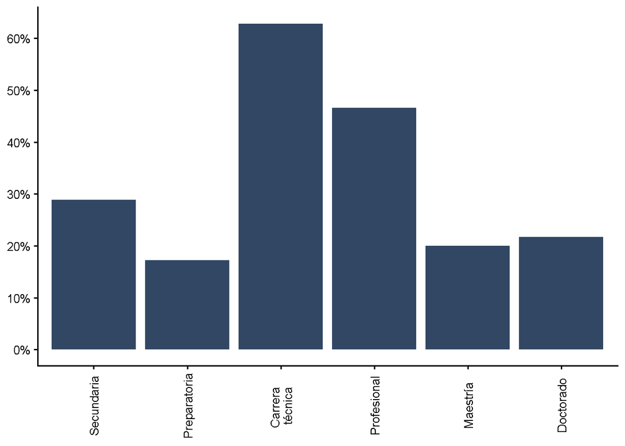

```r
labels_vars1 <- c(
  "3" = "Secundaria",
  "4" = "Preparatoria",
  "6" = "Carrera \ntécnica",
  "7" = "Profesional",
  "8" = "Maestría",
  "9" = "Doctorado"
  )

resultado_jov3 %>%
  filter(desajuste_educativo == 1) %>%
  mutate(escolaridad = factor(escolaridad)) %>%
  ggplot(aes(escolaridad, prop)) +
  geom_col(fill = "#314763") +
  scale_x_discrete(
    labels = labels_vars1
  ) +
  scale_y_continuous(
    labels = scales::label_percent(),
    breaks = seq(0, 0.6, by = 0.1)
  ) +
  theme_classic(base_size = 12, base_family = "Trebuchet MS") +
  theme(
    axis.text.x = element_text(angle = 90, vjust = 0.5)
  ) +
  labs(
    x = NULL,
    y = NULL
  )
```

```r
ggsave(
  "incidencia_jov_escol.png",
  width = 17,
  height = 10,
  units = "cm"
)
```

Por edad entre profesionistas

```r
resultado_jov4 <- objetivo %>%
  filter(between(escolaridad, 5, 9)) %>%
  group_by(edad_7g, desajuste_educativo) %>%
  summarise(
    n = n(),
    tot = sum(fac_tri)
  ) %>%
  mutate(prop = tot / sum(tot))

resultado_jov4 %>%
  filter(desajuste_educativo == 1)
```

```
## # A tibble: 7 × 5
## # Groups:   edad_7g [7]
##   edad_7g desajuste_educativo     n     tot  prop
##   <chr>                 <dbl> <int>   <dbl> <dbl>
## 1 2                         1  4155 1158955 0.642
## 2 3                         1  8439 2471475 0.457
## 3 4                         1  6334 1831241 0.402
## 4 5                         1  4597 1337138 0.418
## 5 6                         1  2837  877794 0.470
## 6 7                         1   875  267388 0.453
## 7 98                        1     7    1681 0.417
```

De forma gráfica

[output not shown]

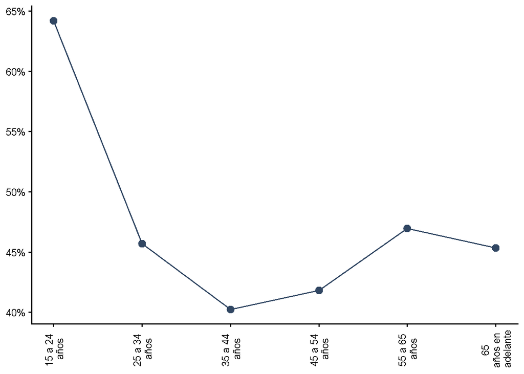

```r
labels_vars1 <- c(
  "2" = "15 a 24 \naños",
  "3" = "25 a 34 \naños",
  "4" = "35 a 44 \naños",
  "5" = "45 a 54 \naños",
  "6" = "55 a 65 \naños",
  "7" = "65 \naños en \nadelante"
  )

resultado_jov4 %>%
  filter(desajuste_educativo == 1 & edad_7g != "98") %>%
  mutate(edad_7g = as.integer(edad_7g)) %>%
  ggplot(aes(edad_7g, prop)) +
  geom_point(color = "#314763", size = 3) +
  geom_line(color = "#314763") +
  theme_classic(base_size = 12, base_family = "Trebuchet MS") +
  scale_x_continuous(
    labels = labels_vars1
  ) +
  scale_y_continuous(
    labels = scales::label_percent(),
    breaks = seq(0, 0.65, by = 0.05)
  ) +
  theme(
    axis.text.x = element_text(angle = 90, vjust = 0.5)
  ) +
  labs(
    x = NULL,
    y = NULL
  )
```

```r
ggsave(
  "incidencia_prof_edad.png",
  width = 17,
  height = 10,
  units = "cm"
)
```

Promedio

```r
resultado_jov4 %>%
  filter(desajuste_educativo == 1 & edad_7g != "98") %>%
  ungroup() %>%
  summarise(
    promedio = mean(prop)
  )
```

```
## # A tibble: 1 × 1
##   promedio
##      <dbl>
## 1    0.474
```

Por entidad federativa

```r
resultado_jov5 <- jov_prof_obj %>%
  group_by(ent, desajuste_educativo) %>%
  summarise(
    n = n(),
    tot = sum(fac_tri)
  ) %>%
  mutate(prop = tot / sum(tot))

resultado_jov5 %>%
  filter(desajuste_educativo == 1) %>%
  arrange(desc(prop))
```

```
## # A tibble: 32 × 5
## # Groups:   ent [32]
##    ent   desajuste_educativo     n    tot  prop
##    <chr>               <dbl> <int>  <dbl> <dbl>
##  1 12                      1   184  48343 0.617
##  2 30                      1   345 127401 0.573
##  3 27                      1   288  51479 0.564
##  4 18                      1   302  28978 0.553
##  5 7                       1   412  74996 0.541
##  6 16                      1   222  94995 0.538
##  7 20                      1   229  54930 0.534
##  8 26                      1   293  83834 0.533
##  9 17                      1   215  42871 0.532
## 10 25                      1   312  93746 0.530
## # ℹ 22 more rows
```

De forma gráfica

```r
# labels_vars1 <- c(
#   "1" = "Aguascalientes",
#   "2" = "Baja California",
#   "3" = "Baja California Sur",
#   "4" = "Campeche",
#   "5" = "Coahuila",
#   "6" = "Colima",
#   "7" = "Chiapas",
#   "8" = "Chihuahua",
#   "9" = "Ciudad de México",
#   "10" = "Durango",
#   "11" = "Guanajuato",
#   "12" = "Guerrero",
#   "13" = "Hidalgo",
#   "14" = "Jalisco",
#   "15" = "México",
#   "16" = "Michoacán",
#   "17" = "Morelos",
#   "18" = "Nayarit",
#   "19" = "Nuevo León",
#   "20" = "Oaxaca",
#   "21" = "Puebla",
#   "22" = "Querétaro",
#   "23" = "Quintana Roo",
#   "24" = "San Luis Potosí",
#   "25" = "Sinaloa",
#   "26" = "Sonora",
#   "27" = "Tabasco",
#   "28" = "Tamaulipas",
#   "29" = "Tlaxcala",
#   "30" = "Veracruz",
#   "31" = "Yucatán",
#   "32" = "Zacatecas"
# )
#
# resultado_jov5 %>%
#   filter(desajuste_educativo == 1) %>%
#   mutate(ent = factor(ent)) %>%
#   ggplot(aes(fct_rev(fct_reorder(ent, prop)), prop)) +
#   geom_col(fill = "#314763") +
#   theme_classic(base_size = 12, base_family = "Trebuchet MS") +
#   scale_x_discrete(
#     labels = labels_vars1
#   ) +
#   scale_y_continuous(
#     labels = scales::label_percent(),
#     breaks = seq(0, 0.6, by = 0.1)
#   ) +
#   theme(
#     axis.text.x = element_text(angle = 90, hjust = 1, vjust = 0.5)
#   ) +
#   labs(
#     x = NULL,
#     y = NULL
#   )
#
# ggsave(
#   "incidencia_jov_prof_ent.png",
#   width = 17,
#   height = 10,
#   units = "cm"
# )
```

De forma gráfica (2)

```r
# paquetes
library(sf)
library(rnaturalearth)
library(rnaturalearthdata)
# library(tidyverse)
library(rnaturalearthhires)

# df
mexico <- ne_states(
  country = "Mexico",
  returnclass = "sf"
)

# nombre de los estados
mexico %>%
  distinct(name)
```

```
##                   name
## 1               Sonora
## 2      Baja California
## 3            Chihuahua
## 4             Coahuila
## 5           Tamaulipas
## 6           Nuevo León
## 7         Quintana Roo
## 8             Campeche
## 9              Tabasco
## 10             Chiapas
## 11              Colima
## 12             Nayarit
## 13 Baja California Sur
## 14             Sinaloa
```

[output cut: 19 more lines]

Se crea la tabla que contiene el id y nombre de cada estado que coincida con los nombres de los paquetes de los mapas

```r
estados <- tribble(
  ~estados,~id,
  "Aguascalientes",1,
  "Baja California",2,
  "Baja California Sur",3,
  "Campeche",4,
  "Coahuila",5,
  "Colima",6,
  "Chiapas",7,
  "Chihuahua",8,
  "Distrito Federal",9,
  "Durango",10,
  "Guanajuato",11,
  "Guerrero",12,
  "Hidalgo",13,
  "Jalisco",14,
  "México",15,
  "Michoacán",16,
  "Morelos",17,
  "Nayarit",18,
  "Nuevo León",19,
  "Oaxaca",20,
  "Puebla",21,
  "Querétaro",22,
  "Quintana Roo",23,
  "San Luis Potosí",24,
  "Sinaloa",25,
  "Sonora",26,
  "Tabasco",27,
  "Tamaulipas",28,
  "Tlaxcala",29,
  "Veracruz",30,
  "Yucatán",31,
  "Zacatecas",32
)

estados <- estados %>%
  mutate(id = as.character(id))
```

Se realiza la unión

```r
resultado_jov_edos <- resultado_jov5 %>%
  left_join(estados, by = c("ent" = "id"))

resultado_jov_edos
```

```
## # A tibble: 64 × 6
## # Groups:   ent [32]
##    ent   desajuste_educativo     n    tot  prop estados
##    <chr>               <dbl> <int>  <dbl> <dbl> <chr>
##  1 1                       0   284  42220 0.613 Aguascalientes
##  2 1                       1   184  26650 0.387 Aguascalientes
##  3 10                      0   309  39156 0.507 Durango
##  4 10                      1   284  38088 0.493 Durango
##  5 11                      0   277 102533 0.531 Guanajuato
##  6 11                      1   249  90698 0.469 Guanajuato
##  7 12                      0   138  30070 0.383 Guerrero
##  8 12                      1   184  48343 0.617 Guerrero
##  9 13                      0   250  45708 0.484 Hidalgo
## 10 13                      1   214  48644 0.516 Hidalgo
## # ℹ 54 more rows
```

De acuerdo a Chat GPT https://chatgpt.com/s/t_695ac37f5f588191997a5560c0415622, se realiza la unión con el df de mapas

```r
mexico_df <- mexico %>%
  left_join(resultado_jov_edos, by = c("name" = "estados"))
```

Se realiza la gráfica

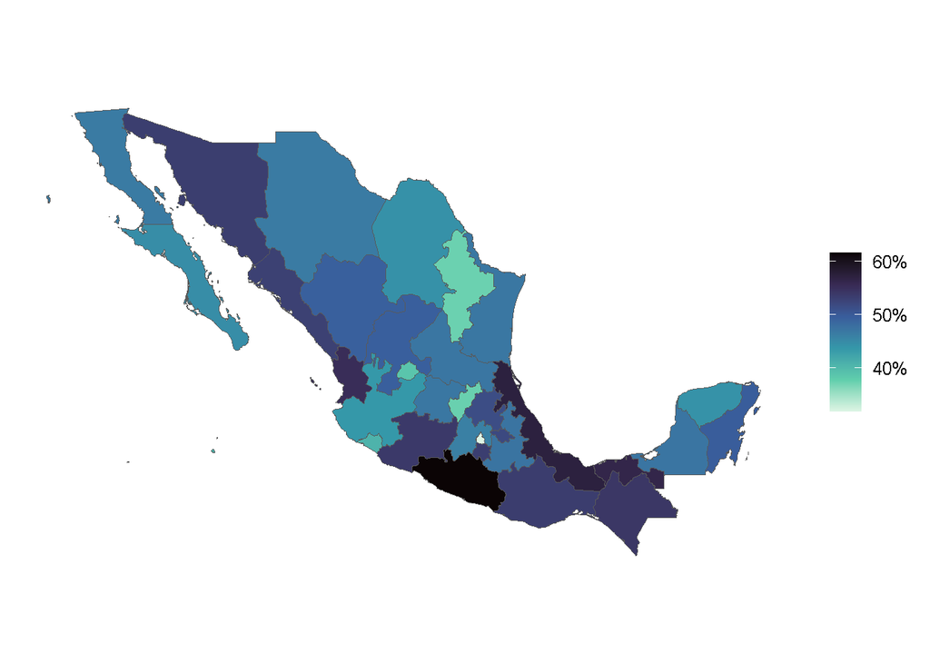

```r
mexico_df %>%
  filter(desajuste_educativo == 1) %>%
  ggplot() +
    geom_sf(aes(fill = prop)) +
    scale_fill_viridis_c(
      # invierte la intensidad del color
      direction = -1,
      # escoger un tema de paleta de color
      option = "G",
      # elimina el título de la leyenda
      name = NULL,
      # convierte a porcentaje
      labels = scales::percent_format(accuracy = 1)
    ) +
    # elimina las coordenadas
    coord_sf(datum = NA) +
    theme_classic(base_size = 12, base_family = "Trebuchet MS")
```

```r
ggsave(
  "incidencia_jov_prof_ent.png",
  width = 17,
  height = 10,
  units = "cm"
)
```

Por carrera educativa amplia

```r
resultado_jov6 <- jov_prof_obj %>%
  group_by(carrera1, desajuste_educativo) %>%
  summarise(
    n = n(),
    tot = sum(fac_tri)
  ) %>%
  mutate(prop = tot / sum(tot))

resultado_jov6 %>%
  filter(desajuste_educativo == 1) %>%
  arrange(desc(prop))
```

```
## # A tibble: 11 × 5
## # Groups:   carrera1 [11]
##    carrera1 desajuste_educativo     n    tot  prop
##    <chr>                  <dbl> <int>  <dbl> <dbl>
##  1 10                         1   561 174119 0.810
##  2 08                         1   205  68436 0.639
##  3 04                         1  2231 656911 0.532
##  4 99                         1    38  13327 0.522
##  5 07                         1  1766 465092 0.467
##  6 06                         1   530 180698 0.462
##  7 03                         1  1500 441694 0.461
##  8 05                         1   201  52241 0.424
##  9 01                         1   533 182295 0.370
## 10 02                         1   267  68288 0.305
## 11 09                         1   607 168374 0.262
```

De forma gráfica

[output not shown]

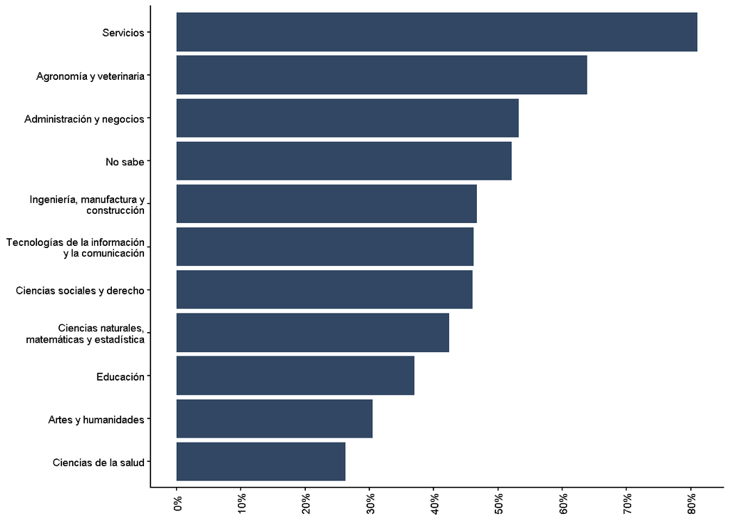

```r
resultado_jov6 %>%
  filter(desajuste_educativo == 1) %>%
  mutate(
    carrera1 = factor(carrera1),
    carrera1 = fct_recode(
      carrera1,
      "Educación" = "01",
      "Artes y humanidades" = "02",
      "Ciencias sociales y derecho" = "03",
      "Administración y negocios" = "04",
      "Ciencias naturales, matemáticas y estadística" = "05",
      "Tecnologías de la información y la comunicación" = "06",
      "Ingeniería, manufactura y construcción" = "07",
      "Agronomía y veterinaria" = "08",
      "Ciencias de la salud" = "09",
      "Servicios" = "10",
      # nivel no registrado en INEGI(2016)
      "No sabe" = "99"

    )
  ) %>%
  ggplot(aes(fct_reorder(carrera1, prop), prop)) +
  geom_col(fill = "#314763") +
  theme_classic(base_size = 9, base_family = "Trebuchet MS") +
  scale_x_discrete(
    labels = scales::label_wrap(width = 30)
  ) +
  scale_y_continuous(
    labels = scales::label_percent(),
    breaks = seq(0, 0.8, by = 0.1)
  ) +
  theme(
    axis.text.x = element_text(angle = 90, vjust = 0.5)
  ) +
  labs(
    x = NULL,
    y = NULL
  ) +
  coord_flip()
```

```r
ggsave(
  "incidencia_jov_prof_carreras.png",
  width = 17,
  height = 10,
  units = "cm"
)
```

Por escolaridad entre jóvenes profesionistas

```r
# resultado_jov7 <- jov_prof_obj %>%
#   group_by(escolaridad, desajuste_educativo) %>%
#   summarise(
#     n = n(),
#     tot = sum(fac_tri)
#   ) %>%
#   mutate(prop = tot / sum(tot))
#
# resultado_jov7 %>%
#   filter(desajuste_educativo == 1) %>%
#   arrange(desc(prop))
```

Por ocupaciones

```r
# resultado_jov8 <- jov_prof_obj %>%
#   group_by(ocupacion1, desajuste_educativo) %>%
#   summarise(
#     n = n(),
#     tot = sum(fac_tri)
#   )
#
# resultado_jov8 %>%
#   filter(desajuste_educativo == 1) %>%
#   arrange(desc(tot))
```

Por nivel de ingresos

```r
resultado_jov9 <- jov_prof_obj %>%
  group_by(ing7c, desajuste_educativo) %>%
  summarise(
    n = n(),
    tot = sum(fac_tri)
  ) %>%
  mutate(prop = tot / sum(tot))

resultado_jov9 %>%
  filter(desajuste_educativo == 1)
```

```
## # A tibble: 7 × 5
## # Groups:   ing7c [7]
##   ing7c desajuste_educativo     n    tot  prop
##   <chr>               <dbl> <int>  <dbl> <dbl>
## 1 1                       1  2459 737336 0.641
## 2 2                       1  3009 829488 0.456
## 3 3                       1   669 194533 0.310
## 4 4                       1   225  61765 0.232
## 5 5                       1    60  19183 0.227
## 6 6                       1   194  63100 0.851
## 7 7                       1  1823 566070 0.408
```

Por prestaciones de salud

```r
# resultado_jov10 <- jov_prof_obj %>%
#   group_by(medica5c, desajuste_educativo) %>%
#   summarise(
#     n = n(),
#     tot = sum(fac_tri)
#   ) %>%
#   mutate(prop = tot / sum(tot))
#
# resultado_jov10 %>%
#   filter(desajuste_educativo == 1)
```

Por búsqueda de otro empleo

```r
# resultado_jov11 <- jov_prof_obj %>%
#   group_by(buscar5c, desajuste_educativo) %>%
#   summarise(
#     n = n(),
#     tot = sum(fac_tri)
#   ) %>%
#   mutate(prop = tot / sum(tot))
#
# resultado_jov11
```

Por sector de actividad agregado

```r
resultado_jov12 <- jov_prof_obj %>%
  group_by(rama_est1, desajuste_educativo) %>%
  summarise(
    n = n(),
    tot = sum(fac_tri)
  ) %>%
  mutate(prop = tot / sum(tot))

resultado_jov12 %>%
  filter(desajuste_educativo == 1)
```

```
## # A tibble: 4 × 5
## # Groups:   rama_est1 [4]
##   rama_est1 desajuste_educativo     n     tot  prop
##   <chr>                   <dbl> <int>   <dbl> <dbl>
## 1 1                           1   196   67959 0.820
## 2 2                           1  1869  526231 0.514
## 3 3                           1  6293 1848115 0.434
## 4 4                           1    81   29170 0.629
```

Por sector de actividad desagregado

```r
# resultado_jov13 <- jov_prof_obj %>%
#   group_by(rama_est2, desajuste_educativo) %>%
#   summarise(
#     n = n(),
#     tot = sum(fac_tri)
#   ) %>%
#   mutate(prop = tot / sum(tot))
#
# resultado_jov13 %>%
#   filter(desajuste_educativo == 1) %>%
#   arrange(desc(prop))
```

Por el tamaño de la unidad económica

```r
resultado_jov14 <- jov_prof_obj %>%
  group_by(ambito2, desajuste_educativo) %>%
  summarise(
    n = n(),
    tot = sum(fac_tri)
  ) %>%
  mutate(prop = tot / sum(tot))

resultado_jov14 %>%
  filter(desajuste_educativo == 1)
```

```
## # A tibble: 8 × 5
## # Groups:   ambito2 [8]
##   ambito2 desajuste_educativo     n    tot  prop
##   <chr>                 <dbl> <int>  <dbl> <dbl>
## 1 0                         1  1180 322407 0.473
## 2 2                         1  1107 320478 0.609
## 3 3                         1  1600 478663 0.558
## 4 4                         1  1640 481847 0.366
## 5 5                         1  1050 335757 0.419
## 6 6                         1  1185 351475 0.420
## 7 7                         1   520 140046 0.421
## 8 8                         1   157  40802 0.742
```

```r
  # arrange(desc(prop))
```

Por tipo de empleo: formal e informal

```r
resultado_jov15 <- jov_prof_obj %>%
  group_by(emp_ppal, desajuste_educativo) %>%
  summarise(
    n = n(),
    tot = sum(fac_tri)
  ) %>%
  mutate(prop = tot / sum(tot))

resultado_jov15 %>%
  filter(desajuste_educativo == 1)
```

```
## # A tibble: 2 × 5
## # Groups:   emp_ppal [2]
##   emp_ppal desajuste_educativo     n     tot  prop
##   <chr>                  <dbl> <int>   <dbl> <dbl>
## 1 1                          1  3109  947631 0.591
## 2 2                          1  5330 1523844 0.401
```

```r
  # arrange(desc(prop))
```

Por buscador de otro trabajo

```r
# resultado_jov16 <- jov_prof_obj %>%
#   group_by(busqueda, desajuste_educativo) %>%
#   summarise(
#     n = n(),
#     tot = sum(fac_tri)
#   ) %>%
#   mutate(prop = tot / sum(tot))
#
# resultado_jov16 %>%
#   filter(desajuste_educativo == 1)
#   # arrange(desc(prop))
```

Por total de trabajos

```r
# resultado_jov17 <- jov_prof_obj %>%
#   group_by(t_tra, desajuste_educativo) %>%
#   summarise(
#     n = n(),
#     tot = sum(fac_tri)
#   ) %>%
#   mutate(prop = tot / sum(tot))
#
# resultado_jov17 %>%
#   filter(desajuste_educativo == 1)
#   # arrange(desc(prop))
```

## Ingreso mensual

General

```r
objetivo %>%
  filter(!is.na(ingreso_mensual)) %>%
  group_by(desajuste_educativo) %>%
  summarise(
    promedio = survey_mean(ingreso_mensual, vartype = NULL)
  )
```

```
## # A tibble: 4 × 2
##   desajuste_educativo promedio
##                 <dbl>    <dbl>
## 1                   0   11279.
## 2                   1    9166.
## 3                   2    8847.
## 4                  NA    9238.
```

Jóvenes profesionistas

```r
jov_prof_obj %>%
  filter(!is.na(ingreso_mensual)) %>%
  group_by(desajuste_educativo) %>%
  summarise(
    promedio = survey_mean(ingreso_mensual, vartype = NULL)
  )
```

```
## # A tibble: 2 × 2
##   desajuste_educativo promedio
##                 <dbl>    <dbl>
## 1                   0   17382.
## 2                   1   11596.
```

Diagrama de caja

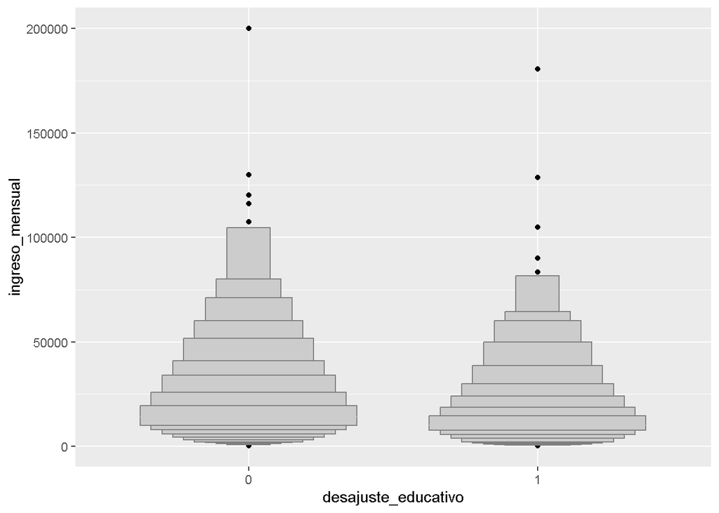

```r
jov_prof_obj %>%
  filter(!is.na(ingreso_mensual)) %>%
  mutate(desajuste_educativo = factor(desajuste_educativo)) %>%
  ggplot(aes(desajuste_educativo, ingreso_mensual)) +
  geom_lv()
```